# Draft climate change exploration in Claremont, CA

Charlotte Chang

2020-09-09

## Description of this document

All of the code can also be found at [Project Guide 2](https://raw.githubusercontent.com/marclos/Climate_Change_Narratives/master/Analysis_Resources/2_Using_NOAA_Climate_Records.pdf) and [Project Guide 3](https://raw.githubusercontent.com/marclos/Climate_Change_Narratives/master/Analysis_Resources/3_Evaluating_Monthly_Trends_CHCNDaily.pdf) and the instructions for this weekend’s assignments are at the [Climate Narratives Project Guide](https://raw.githubusercontent.com/marclos/Climate_Change_Narratives/master/Admin/Project_Guide/Climate_Narratives_F20.pdf). The [blog template assignment](https://sakai.claremont.edu/portal/directtool/b68fbfea-ce8b-4ac2-9006-9fd3bf97b5b2/) can be seen in the [Climate Narratives Project Guide](https://raw.githubusercontent.com/marclos/Climate_Change_Narratives/master/Admin/Project_Guide/Climate_Narratives_F20.pdf) in **section 6**. My other “skeleton outline” document (`~/Climate_Change_Narratives/Student_Folders/Chang/Regional_Trend_Skeleton.Rmd`) shows an example if you would like to work through that and modify it to fit your own data; that assignment is described in **section 8.1** (*not 8.2*!) for the [draft regional analysis](https://sakai.claremont.edu/portal/directtool/b68fbfea-ce8b-4ac2-9006-9fd3bf97b5b2/).

Below I show how to include a graphic from a URL link or from a local file in a `RMarkdown` document.

[figure not shown]

View from Johnson’s Pasture in Claremont, California

## Example overview

This blog will examine climate change through the perspective of temperature trends in the summertime and precipitation trends in the winter in Claremont, California.

Variables examined will include:

- Temperature (degrees Celsius)
  - I will personally convert the temperatures to Fahrenheit which is a far worse system but oh well.
- Precipitation (mm/day) - (just joking! didn’t work through that in this example; see [Project Guide 3](https://raw.githubusercontent.com/marclos/Climate_Change_Narratives/master/Analysis_Resources/3_Evaluating_Monthly_Trends_CHCNDaily.pdf) from page 17 onwards for guidance)

#### Temperature exploration

Below is a plot of all daily `TMAX` values over the full set of observations for Claremont, CA.

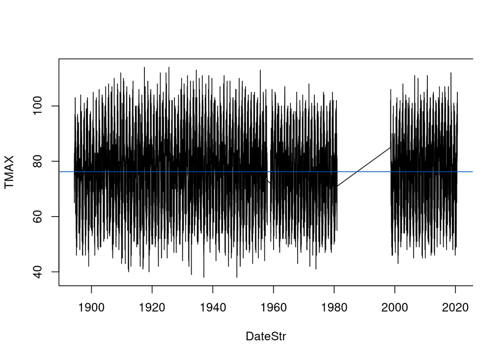

Yikes! That plot looks pretty horrible. Let’s take a look at monthly averages of daily `TMAX`.

[figure not shown]

#### September is hot!

*Are September daily max temps getting warmer in Claremont on average?*

In the Southwest of the continental US, it appears that our summer and late-summer months have experienced warming. As such, I am going to drill down on the month of September. I’ve plotted September data below and have created a best-fit line (linear model/ordinary least squares model) for monthly September averages of daily `TMAX` against year to see if there is some type of discernible trend.

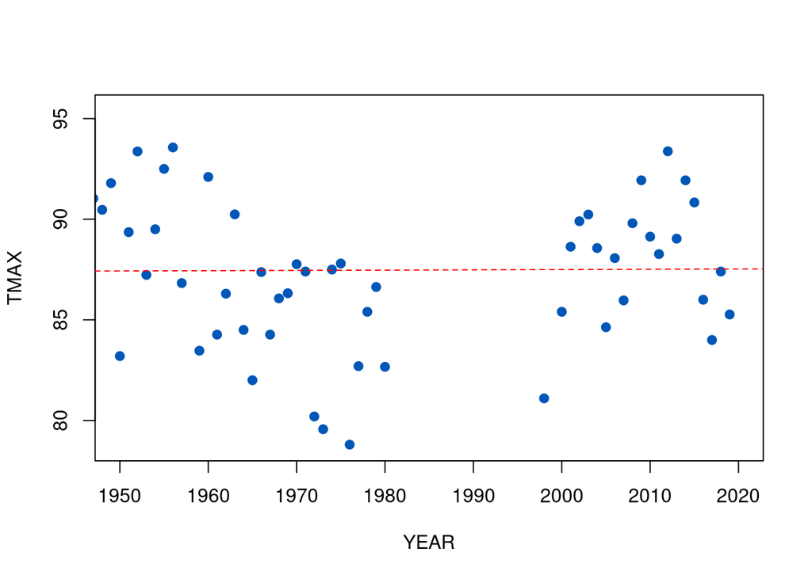

How would you improve this rough, initial plot? Perhaps we would want to modify `xlab`, `ylab`, and `las`. What else would we perhaps like to modify? See `?par` in the console for more details or the [Overview of R document](https://sakai.claremont.edu/portal/directtool/b68fbfea-ce8b-4ac2-9006-9fd3bf97b5b2/).